# ArabicaAI · Contact center & fraud prevention

## tl;dr

**Reviewed full-data snapshot · 26 September 2026.** 4,389 CSV files verified by S3 object name and size. Event dates span 17 June 2023–18 June 2026; process partitions end 17 June 2026. These are synthetic data, not real-bank rates.

- **Contact demand:** 240,056 / 686,296 contacts (34.98%) are `Transaccional`, with documented FCR 91.51%. This broad label does not identify specific transaction disputes.
- **Service friction:** `Queja` has 117,021 contacts, documented FCR 43.60% (51,021/117,021), and follow-up 62.97% (73,686/117,021). It accounts for 66,000/160,266 recorded unresolved contacts (41.18%). These three flags have no unknown values in this run.
- **Fraud:** 4,316/4,425,008 transactions are labeled fraud (0.0975%); unknown labels: 0. Channel and amount-band differences are exploratory, not validated prevention rules.
- **Linkage limit:** all 67,095 complaints lack `origin_interaction_id`; there is no documented complaint-to-transaction key. Dispute intake remains a conditional candidate, not a proven end-to-end historical workflow.

**Recommendation for discussion:** prioritize a narrow complaint/suspicious-charge intake and human-handoff slice, with transactional inquiries as the lower-risk comparator. Continue fraud-prevention feature and label-timing investigation separately. No prevention model or business improvement has been demonstrated.

The narrative describes this reviewed snapshot. If inputs change, update it after reviewing the new outputs; the manifest hash and execution time are recorded below.

## Context & Methods

Official sources: `Docs/sources/LATAM_Bank_Complete_Data_Dictionary (1).pdf` pp. 7–12; dataset summary pp. 1–5; hackathon problem statement pp. 2–6; `BUSINESS_OUTCOMES.md`. The dictionary is the schema reference; actual CSV values are reported without translating categories.

### Key Assumptions

- Synthetic historical records do not establish real-bank prevalence or causal effects. All verified supplied partitions are used. Source timestamps have no documented timezone; no timezone is inferred.
- Primary metrics retain only nonblank IDs occurring exactly once across all partitions. Every duplicate occurrence is excluded; raw-row comparisons reveal sensitivity. No silent deduplication.
- Rates use known valid values and display numerator, denominator and unknown count. Documented FCR is the supplied `was_resolved` flag, not independently proven absence of repeat contacts. Unknown is never false.
- Customer country enrichment uses only unambiguous dimension keys; it is a current snapshot, not historical country at event time. Facts are never joined directly to each other by customer ID.
- Open complaints are excluded from resolved-case duration summaries. Money is summed within currency; USD missingness remains visible. Fraud-labeled amounts are exposure, not realized loss.
- `is_fraud` is the target; `fraud_score` needs timing/provenance verification; `transaction_status` and `response_code` may be post-decision. No model is trained. Any future history feature must use only prior events.
- Exact duplicate counts and sorts are disk-backed. Python retains bounded batches and compact aggregates; SQLite uses a 32 MiB cache. Input verification compares object names/sizes, not cryptographic S3 content checksums.

### 1. Parameters and environment

Run from the repository or its `notebooks/` directory. Override paths through the environment variables below. See `notebooks/README.md` for setup and manifest generation. A full run rebuilds an ignored analytical SQLite file and may take several minutes.

```
Run: full | Python: 3.12.14
```

## Data

### 2. Verify inputs, load once, calculate

The manifest lists exact expected CSV objects. Missing/extra files, size mismatches, malformed rows and required-column failures stop execution. Every file is checked for changes while it is read. The output below identifies raw and analytical populations; published tables contain aggregates only.

```
call_center_interactions: 200/1097 files
```

```
call_center_interactions: 400/1097 files
```

```
call_center_interactions: 600/1097 files
```

```
call_center_interactions: 800/1097 files
```

```
call_center_interactions: 1000/1097 files
```

```
transactions: 200/1097 files
```

```
transactions: 400/1097 files
```

```
transactions: 600/1097 files
```

```
transactions: 800/1097 files
```

```
transactions: 1000/1097 files
```

```
complaints: 200/1097 files
```

```
complaints: 400/1097 files
```

```
complaints: 600/1097 files
```

```
complaints: 800/1097 files
```

```
complaints: 1000/1097 files
```

```
call_transcripts: 200/1097 files
```

```
call_transcripts: 400/1097 files
```

```
call_transcripts: 600/1097 files
```

```
call_transcripts: 800/1097 files
```

```
call_transcripts: 1000/1097 files
```

```
call_center_interactions: grouped counts complete
```

```
complaints: grouped counts complete
```

```
transactions: grouped counts complete
```

```
{
  "run_label": "full",
  "executed_utc": "2026-09-26T17:10:43.499186+00:00",
  "manifest_sha256": "666d1d0dae09952fbdaecf3d8313c95f3afc393898f217e66bb8712f28d69a9c",
  "verified_files": 4389,
  "verified_bytes": 1150192216,
  "python": "3.12.14",
  "helper_sha256": "f3bbcc15c6d75aa21f211492536ab71c511e19c7d28d17831755f893cbd13773"
}
```

| table | files | raw | eligible | blank_rows |
| --- | --- | --- | --- | --- |
| call_center_interactions | 1,097 | 686,296 | 686,296 | 0 |
| transactions | 1,097 | 4,425,008 | 4,425,008 | 0 |
| complaints | 1,097 | 67,095 | 67,095 | 0 |
| customers | 1 | 150,000 | 150,000 | 0 |
| call_transcripts | 1,097 | 171,321 | 171,321 | 0 |

| table | distinct_ids | duplicate_keys | duplicate_rows | conflicting_keys |
| --- | --- | --- | --- | --- |
| call_center_interactions | 686,296 | 0 | 0 | 0 |
| transactions | 4,425,008 | 0 | 0 | 0 |
| complaints | 67,095 | 0 | 0 | 0 |
| customers | 150,000 | 0 | 0 | 0 |
| call_transcripts | 171,321 | 0 | 0 | 0 |

### Actual source schemas versus the dictionary

Only headers are read for this audit; no raw records are displayed. Full documented column lists come from the original data dictionary PDF. Columns omitted from analytical projection are not schema drift. Header agreement does not prove value-domain agreement: country aliases and broad Spanish contact reasons require interpretation as noted below.

**call_center_interactions: 1 observed header variant(s)**

1,097 files · 21 source columns · 21 analyzed columns

`interaction_id`, `interaction_date`, `process_date`, `customer_id`, `agent_id`, `interaction_type`, `channel`, `contact_reason`, `reason_category`, `duration_seconds`, `wait_time_seconds`, `was_resolved`, `requires_followup`, `detected_sentiment`, `sentiment_score`, `customer_detected_accent`, `agent_used_accent`, `was_escalated`, `mentioned_products`, `has_transcript`, `has_recording`

**transactions: 1 observed header variant(s)**

1,097 files · 22 source columns · 22 analyzed columns

`transaction_id`, `transaction_date`, `process_date`, `product_id`, `customer_id`, `transaction_type`, `transaction_category`, `amount`, `currency`, `amount_usd`, `channel`, `branch_id`, `merchant_name`, `merchant_category`, `transaction_country`, `transaction_city`, `transaction_status`, `response_code`, `is_fraud`, `fraud_score`, `latitude`, `longitude`

**complaints: 1 observed header variant(s)**

1,097 files · 27 source columns · 17 analyzed columns

`complaint_id`, `creation_date`, `process_date`, `customer_id`, `case_type`, `category`, `subcategory`, `reception_channel`, `affected_product_id`, `related_branch_id`, `origin_interaction_id`, `description`, `claimed_amount`, `currency`, `priority`, `status`, `assigned_agent_id`, `assignment_date`, `first_response_date`, `resolution_date`, `closing_date`, `sla_breached`, `resolution_days`, `resolution`, `compensation_granted`, `resolution_satisfaction`, `is_repeat_complainer`

**customers: 1 observed header variant(s)**

1 files · 27 source columns · 2 analyzed columns

`customer_id`, `document_number`, `document_type`, `first_name`, `last_name`, `date_of_birth`, `gender`, `email`, `mobile_phone`, `landline_phone`, `address`, `city`, `state`, `country`, `postal_code`, `detected_accent`, `segment`, `credit_score`, `estimated_monthly_income`, `occupation`, `marital_status`, `education_level`, `registration_date`, `registration_branch_id`, `customer_status`, `last_updated`, `accepts_marketing`

**call_transcripts: 1 observed header variant(s)**

1,097 files · 18 source columns · 4 analyzed columns

`transcript_id`, `interaction_id`, `process_date`, `customer_id`, `agent_id`, `full_text`, `customer_text`, `agent_text`, `detected_language`, `detected_accent`, `accent_confidence`, `detected_keywords`, `mentioned_entities`, `detected_intents`, `main_topics`, `transcription_model`, `audio_quality`, `duration_seconds`

| table | files | missing_documented | undocumented |
| --- | --- | --- | --- |
| call_center_interactions | 1,097 | None | None |
| transactions | 1,097 | None | None |
| complaints | 1,097 | None | None |
| customers | 1 | None | None |
| call_transcripts | 1,097 | None | None |

### 3. Coverage, unknowns and join quality

Dates below describe eligible records. Later process dates can reflect delayed arrival; event dates after the process date are flagged separately. Their meaning requires confirmation of timezone and processing-day semantics. Documentation row counts are approximate and are not substituted for measured counts.

**Observed:** the measured primary populations are 686,296 interactions, 4,425,008 transactions and 67,095 complaints—below the dictionary's approximate 800,000 / 5,000,000 / 80,000 counts despite complete required-object coverage. No blank or duplicate IDs were found in these five loaded tables. This is not a certification of every field or all 13 source tables. Event dates after process dates are common; clarify processing-day/timezone semantics before operational freshness rules.

| table | eligible | dated | first_event | last_event |
| --- | --- | --- | --- | --- |
| call_center_interactions | 686,296 | 686,296 | 2023-06-17 08:03:26 | 2026-06-18 07:58:13 |
| complaints | 67,095 | 67,095 | 2023-06-17 08:07:05 | 2026-06-18 07:56:52 |
| transactions | 4,425,008 | 4,425,008 | 2023-06-17 06:01:30 | 2026-06-18 05:59:41 |

| table | first_process | last_process | later_process | event_after_process |
| --- | --- | --- | --- | --- |
| call_center_interactions | 2023-06-17 | 2026-06-17 | 0 | 228,318 |
| complaints | 2023-06-17 | 2026-06-17 | 0 | 22,585 |
| transactions | 2023-06-17 | 2026-06-17 | 0 | 1,106,307 |

| table | field_issue | raw_rows |
| --- | --- | --- |
| transactions | longitude:missing | 3,567,715 |
| transactions | latitude:missing | 3,567,680 |
| transactions | merchant_category:missing | 3,396,215 |
| transactions | merchant_name:missing | 3,395,774 |
| transactions | branch_id:missing | 3,037,076 |
| transactions | transaction_category:missing | 2,693,520 |
| transactions | amount_usd:missing | 2,537,456 |
| transactions | fraud_score:missing | 885,157 |
| transactions | transaction_city:missing | 442,611 |
| call_center_interactions | mentioned_products:missing | 411,955 |
| transactions | response_code:missing | 221,033 |
| call_center_interactions | wait_time_seconds:missing | 205,618 |
| call_center_interactions | agent_used_accent:missing | 204,750 |
| call_center_interactions | customer_detected_accent:missing | 204,750 |
| call_center_interactions | duration_seconds:missing | 96,234 |
| complaints | origin_interaction_id:missing | 67,095 |
| complaints | resolution_date:missing | 51,746 |
| complaints | resolution_days:missing | 51,732 |
| complaints | claimed_amount:missing | 45,344 |
| complaints | currency:missing | 45,319 |

| table | match_status | rows |
| --- | --- | --- |
| call_center_interactions | matched | 686,296 |
| complaints | matched | 67,095 |
| transactions | matched | 4,425,008 |

## Results

### 4. What brings customers to the contact center?

Bars count eligible interactions, not unique customers. The table compares raw-row shares with eligible shares so exclusions remain visible. Up to 100 categories per dimension are retained; figures show at most ten. Exact total counts remain untruncated.

**Observed:** transactional contacts represent 34.98% of interactions. `contact_reason` contains broad categories, so identifying a specific customer intent requires a separate labeled-text review. With no duplicate/blank IDs here, raw and eligible rankings coincide.

| label | eligible | raw | eligible_share | raw_share | share_change_pp |
| --- | --- | --- | --- | --- | --- |
| Transaccional | 240,056 | 240,056 | 34.978% | 34.978% | 0.00 |
| Producto | 150,863 | 150,863 | 21.982% | 21.982% | 0.00 |
| Queja | 117,021 | 117,021 | 17.051% | 17.051% | 0.00 |
| Técnico | 102,899 | 102,899 | 14.993% | 14.993% | 0.00 |
| Comercial | 54,879 | 54,879 | 7.996% | 7.996% | 0.00 |
| Retención | 20,578 | 20,578 | 2.998% | 2.998% | 0.00 |

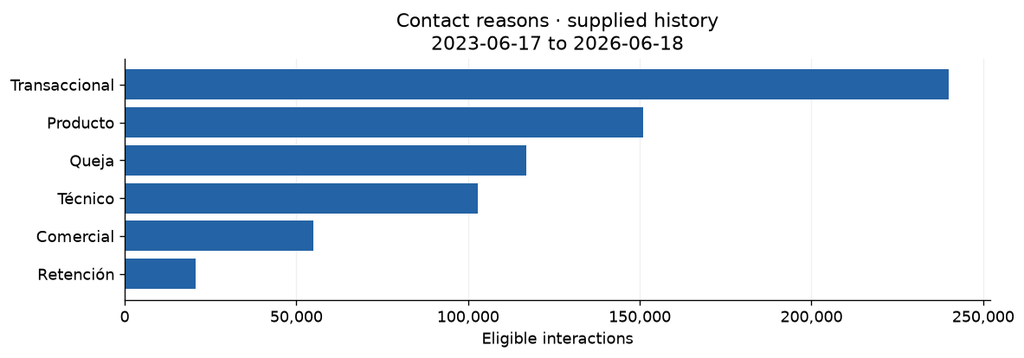

| label | rows |
| --- | --- |
| Transaccional | 240,056 |
| Producto | 150,863 |
| Queja | 117,021 |
| Técnico | 102,899 |
| Comercial | 54,879 |
| Retención | 20,578 |

### 5. Resolution, follow-up and escalation

Rates use known values for each flag; their denominators can differ. The chart is descriptive and does not establish that one type of contact causes escalation. The consistency table checks cases marked resolved that still require follow-up.

**Observed:** complaint-related contacts have 43.60% documented FCR versus 91.51% for transactional contacts. Their median measured duration is 431 seconds (100,727 known values) versus 205 seconds (206,465 known values). Duration is missing for 96,234/686,296 contacts; wait time for 205,618/686,296. Also, 78,788 contacts are marked both resolved and requiring follow-up: clarify the flag semantics before calling this independently verified first-contact resolution.

| label | metric | numerator | denominator | unknown | eligible | rate |
| --- | --- | --- | --- | --- | --- | --- |
| Transaccional | was_resolved | 219,671 | 240,056 | 0 | 240,056 | 91.508% |
| Producto | was_resolved | 135,213 | 150,863 | 0 | 150,863 | 89.626% |
| Queja | was_resolved | 51,021 | 117,021 | 0 | 117,021 | 43.600% |
| Técnico | was_resolved | 71,959 | 102,899 | 0 | 102,899 | 69.932% |
| Comercial | was_resolved | 35,786 | 54,879 | 0 | 54,879 | 65.209% |
| Retención | was_resolved | 12,380 | 20,578 | 0 | 20,578 | 60.161% |
| Transaccional | requires_followup | 53,137 | 240,056 | 0 | 240,056 | 22.135% |
| Producto | requires_followup | 35,923 | 150,863 | 0 | 150,863 | 23.812% |
| Queja | requires_followup | 73,686 | 117,021 | 0 | 117,021 | 62.968% |
| Técnico | requires_followup | 41,763 | 102,899 | 0 | 102,899 | 40.586% |
| Comercial | requires_followup | 24,446 | 54,879 | 0 | 54,879 | 44.545% |
| Retención | requires_followup | 10,099 | 20,578 | 0 | 20,578 | 49.077% |
| Transaccional | was_escalated | 23,841 | 240,056 | 0 | 240,056 | 9.931% |
| Producto | was_escalated | 15,021 | 150,863 | 0 | 150,863 | 9.957% |
| Queja | was_escalated | 11,733 | 117,021 | 0 | 117,021 | 10.026% |
| Técnico | was_escalated | 10,367 | 102,899 | 0 | 102,899 | 10.075% |
| Comercial | was_escalated | 5,398 | 54,879 | 0 | 54,879 | 9.836% |
| Retención | was_escalated | 2,026 | 20,578 | 0 | 20,578 | 9.845% |
| Transaccional | has_transcript | 59,786 | 240,056 | 0 | 240,056 | 24.905% |
| Producto | has_transcript | 37,658 | 150,863 | 0 | 150,863 | 24.962% |
| Queja | has_transcript | 29,198 | 117,021 | 0 | 117,021 | 24.951% |
| Técnico | has_transcript | 25,691 | 102,899 | 0 | 102,899 | 24.967% |
| Comercial | has_transcript | 13,808 | 54,879 | 0 | 54,879 | 25.161% |
| Retención | has_transcript | 5,180 | 20,578 | 0 | 20,578 | 25.173% |

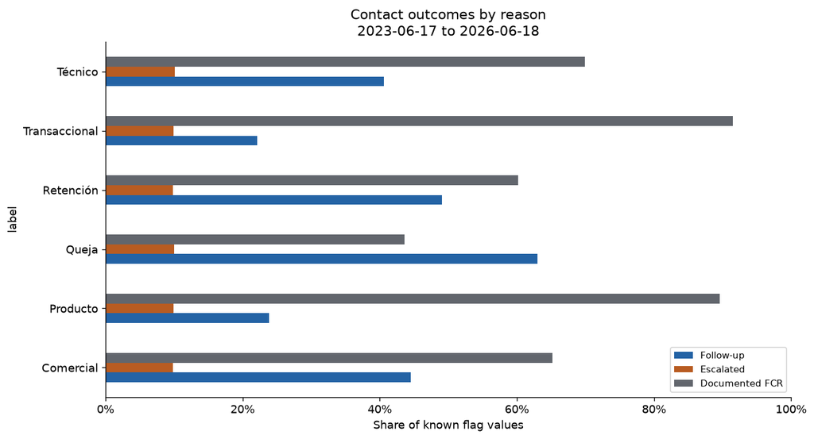

| eligible_interactions | resolved_with_followup | known_both |
| --- | --- | --- |
| 686,296 | 78,788 | 686,296 |

| metric | dimension | label | known | median | p95 |
| --- | --- | --- | --- | --- | --- |
| duration_seconds | all | All | 590,062 | 291.00 | 614.00 |
| duration_seconds | contact_reason | Transaccional | 206,465 | 205.00 | 408.00 |
| duration_seconds | contact_reason | Producto | 129,644 | 263.00 | 415.00 |
| duration_seconds | contact_reason | Queja | 100,727 | 431.00 | 663.00 |
| duration_seconds | contact_reason | Técnico | 88,493 | 360.00 | 539.00 |
| duration_seconds | contact_reason | Comercial | 47,082 | 540.00 | 808.00 |
| duration_seconds | contact_reason | Retención | 17,651 | 478.00 | 720.00 |
| wait_time_seconds | all | All | 480,678 | 119.00 | 218.00 |
| wait_time_seconds | contact_reason | Transaccional | 168,074 | 119.00 | 217.00 |
| wait_time_seconds | contact_reason | Producto | 105,610 | 119.00 | 217.00 |
| wait_time_seconds | contact_reason | Queja | 82,261 | 120.00 | 219.00 |
| wait_time_seconds | contact_reason | Técnico | 71,974 | 119.00 | 219.00 |
| wait_time_seconds | contact_reason | Comercial | 38,338 | 120.00 | 218.00 |
| wait_time_seconds | contact_reason | Retención | 14,421 | 120.00 | 219.00 |

### 6. Channel, country and time

Country is a customer snapshot and is unknown for missing or ambiguous customer keys. Boundary months may be partial; a low count in a partial month is not a demand decline.

| label | numerator | denominator | unknown | rate |
| --- | --- | --- | --- | --- |
| Phone | 446,931 | 583,250 | 0 | 76.628% |
| Email | 21,155 | 27,543 | 0 | 76.807% |
| App | 20,334 | 26,364 | 0 | 77.128% |
| WhatsApp | 17,527 | 22,888 | 0 | 76.577% |
| Web Chat | 17,479 | 22,856 | 0 | 76.474% |
| Web | 2,604 | 3,395 | 0 | 76.701% |

| label | numerator | denominator | unknown | rate |
| --- | --- | --- | --- | --- |
| México | 263,079 | 343,189 | 0 | 76.657% |
| Colombia | 158,551 | 206,790 | 0 | 76.672% |
| Argentina | 104,400 | 136,317 | 0 | 76.586% |

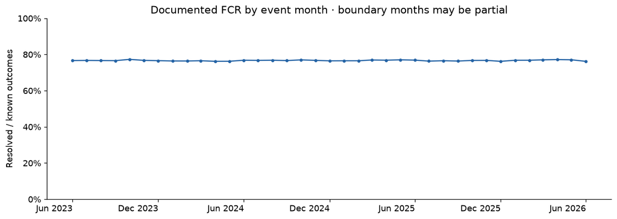

### 7. Supporting complaint and language evidence

Complaint records have their own grain; they are not added to interaction counts. SLA breach is a supplied flag. Resolved-case duration includes only Resolved/Closed cases with valid creation/resolution dates, nonnegative duration and resolution on/after creation. Open cases remain visible and are not assigned zero duration. Transcript metadata is not evidence of full population language coverage.

**Observed:** complaint SLA breaches are 13,495/67,095 (20.11%). `Cargo no reconocido` appears on 12,297 complaints, and `Cobro indebido` on 12,194; these are complaint subcategory labels, not confirmed fraud. All 67,095 originating-interaction links are blank, so no complaint-to-call performance claim is supported. The 171,321 transcripts are all labeled Spanish (`es`) and have unambiguous interaction references; they cover about a quarter of contacts, not the full population. Portuguese evaluation cases still need to be built.

| label | eligible | numerator | denominator | unknown | rate |
| --- | --- | --- | --- | --- | --- |
| Transactions | 13,580 | 2,739 | 13,580 | 0 | 20.169% |
| Fees | 13,553 | 2,680 | 13,553 | 0 | 19.774% |
| Technical | 13,407 | 2,681 | 13,407 | 0 | 19.997% |
| Branch | 13,361 | 2,724 | 13,361 | 0 | 20.388% |
| Service | 13,194 | 2,671 | 13,194 | 0 | 20.244% |

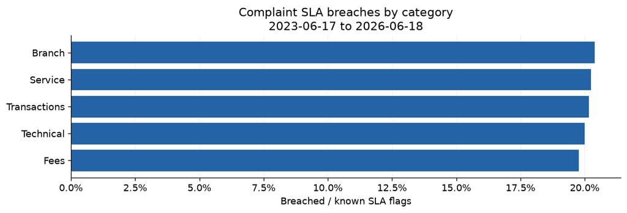

| label | rows |
| --- | --- |
| In Process | 26,823 |
| Open | 20,125 |
| Resolved | 13,512 |
| Escalated | 3,321 |
| Closed | 2,609 |
| Rejected | 705 |

| dimension | label | known | median | p95 |
| --- | --- | --- | --- | --- |
| all | All | 14,626 | 16.00 | 29.00 |
| category | Transactions | 3,014 | 15.00 | 29.00 |
| category | Branch | 2,928 | 16.00 | 29.00 |
| category | Fees | 2,928 | 16.00 | 29.00 |
| category | Technical | 2,895 | 16.00 | 29.00 |
| category | Service | 2,861 | 16.00 | 29.00 |

| language | transcripts | missing_interaction | ambiguous_interaction |
| --- | --- | --- | --- |
| es | 171,321 | 0 | 0 |

| label | rows |
| --- | --- |
| Cargo no reconocido | 12,297 |
| Cobro indebido | 12,194 |
| Problema con app | 12,128 |
| Atención en sucursal | 11,892 |
| Calidad de servicio | 11,886 |
| Unknown | 6,698 |

| metric | numerator | denominator | unknown | eligible | rate |
| --- | --- | --- | --- | --- | --- |
| is_repeat_complainer | 10,086 | 67,095 | 0 | 67,095 | 15.032% |

### 8. Fraud labels: where is the observed exposure?

The following rates describe synthetic labeled transactions. They do not measure prevention effectiveness, model precision/recall or money recovered. Status breakdowns are descriptive outcomes, not assumed pre-authorization features. Unknown fraud labels remain outside the known-label denominator.

Country labels are preserved as supplied; `Mexico` and `México` can both appear. Treat these as a naming-quality issue, not different countries. Resolve aliases before using geography in a prevention rule. Small groups can produce unstable rates.

**Observed:** prevalence is 0.0975%; a constant non-fraud prediction would have 99.9025% accuracy while detecting none of the labeled fraud. This arithmetic illustrates why accuracy alone is unsuitable; it is not an evaluated prevention model. Channel rates range from 0.0948% (POS) to 0.1079% (Branch). Do not treat this small descriptive spread as a validated blocking policy.

| numerator | denominator | unknown | eligible | rate |
| --- | --- | --- | --- | --- |
| 4,316 | 4,425,008 | 0 | 4,425,008 | 0.098% |

| label | numerator | denominator | unknown | rate |
| --- | --- | --- | --- | --- |
| POS | 1,467 | 1,548,161 | 0 | 0.095% |
| ATM | 1,331 | 1,328,334 | 0 | 0.100% |
| Web | 656 | 663,445 | 0 | 0.099% |
| App | 634 | 663,414 | 0 | 0.096% |
| Branch | 143 | 132,495 | 0 | 0.108% |
| Transfer | 85 | 89,159 | 0 | 0.095% |

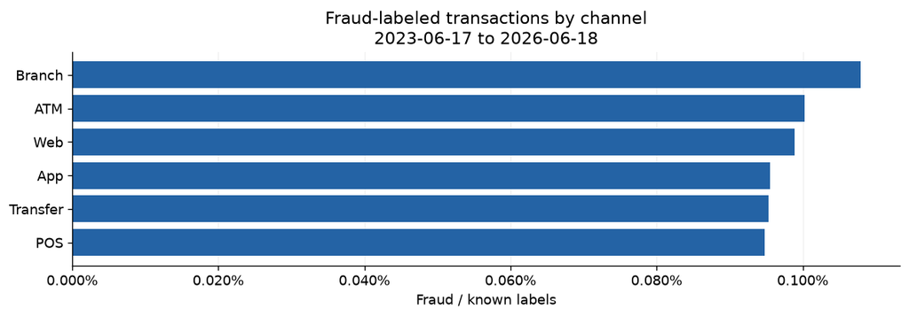

| label | numerator | denominator | unknown | rate |
| --- | --- | --- | --- | --- |
| Purchase | 1,086 | 1,083,406 | 0 | 0.100% |
| Withdrawal | 951 | 964,673 | 0 | 0.099% |
| Transfer | 798 | 896,438 | 0 | 0.089% |
| Payment | 730 | 738,964 | 0 | 0.099% |
| Deposit | 607 | 609,409 | 0 | 0.100% |
| Adjustment | 144 | 132,118 | 0 | 0.109% |

| label | numerator | denominator | unknown | rate |
| --- | --- | --- | --- | --- |
| México | 2,082 | 2,105,794 | 0 | 0.099% |
| Colombia | 1,198 | 1,289,503 | 0 | 0.093% |
| Argentina | 864 | 867,561 | 0 | 0.100% |
| USA | 38 | 40,621 | 0 | 0.094% |
| Spain | 39 | 40,542 | 0 | 0.096% |
| Mexico | 50 | 40,515 | 0 | 0.123% |
| Brazil | 45 | 40,472 | 0 | 0.111% |

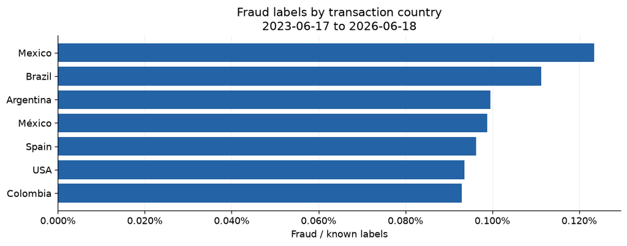

| label | numerator | denominator | unknown | rate |
| --- | --- | --- | --- | --- |
| Unknown | 2,603 | 2,693,520 | 0 | 0.097% |
| Food | 424 | 432,468 | 0 | 0.098% |
| Services | 341 | 345,370 | 0 | 0.099% |
| Other | 267 | 260,518 | 0 | 0.102% |
| Transport | 243 | 260,316 | 0 | 0.093% |
| Entertainment | 253 | 259,643 | 0 | 0.097% |
| Health | 185 | 173,173 | 0 | 0.107% |

| label | numerator | denominator | unknown | rate |
| --- | --- | --- | --- | --- |
| Approved | 3,986 | 4,070,681 | 0 | 0.098% |
| Declined | 215 | 221,234 | 0 | 0.097% |
| Pending | 79 | 88,343 | 0 | 0.089% |
| Reversed | 36 | 44,750 | 0 | 0.080% |

### Prevention signals to investigate next

Fixed USD bands and event-hour groups examine variables potentially available at decision time. Bands are descriptive choices, not tuned thresholds. The timezone of event timestamps is unspecified, so hours must not be interpreted as customer-local time. Group differences are exploratory; an out-of-time test and label-availability audit are still needed.

| label | numerator | denominator | unknown | eligible | rate |
| --- | --- | --- | --- | --- | --- |
| Unknown | 2,508 | 2,537,456 | 0 | 2,537,456 | 0.099% |
| 100–<1,000 USD | 924 | 994,525 | 0 | 994,525 | 0.093% |
| 1,000+ USD | 700 | 719,356 | 0 | 719,356 | 0.097% |
| 0–<100 USD | 184 | 173,671 | 0 | 173,671 | 0.106% |

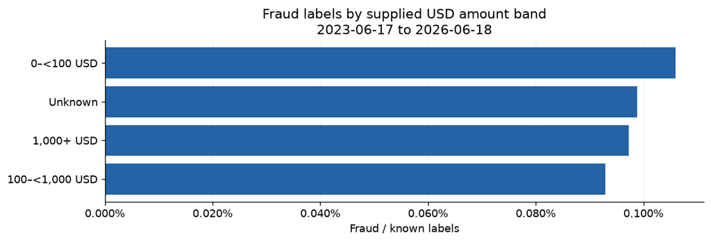

| label | numerator | denominator | unknown | rate |
| --- | --- | --- | --- | --- |
| 00 | 196 | 184,209 | 0 | 0.106% |
| 01 | 164 | 184,821 | 0 | 0.089% |
| 02 | 170 | 184,557 | 0 | 0.092% |
| 03 | 180 | 184,578 | 0 | 0.098% |
| 04 | 177 | 183,734 | 0 | 0.096% |
| 05 | 176 | 184,357 | 0 | 0.095% |
| 06 | 190 | 184,068 | 0 | 0.103% |
| 07 | 199 | 184,301 | 0 | 0.108% |
| 08 | 189 | 183,747 | 0 | 0.103% |
| 09 | 199 | 184,764 | 0 | 0.108% |
| 10 | 175 | 183,991 | 0 | 0.095% |
| 11 | 179 | 184,169 | 0 | 0.097% |
| 12 | 190 | 184,227 | 0 | 0.103% |
| 13 | 180 | 184,648 | 0 | 0.097% |
| 14 | 177 | 184,612 | 0 | 0.096% |
| 15 | 164 | 184,479 | 0 | 0.089% |
| 16 | 170 | 184,434 | 0 | 0.092% |
| 17 | 166 | 184,500 | 0 | 0.090% |
| 18 | 171 | 185,224 | 0 | 0.092% |
| 19 | 165 | 183,570 | 0 | 0.090% |
| 20 | 188 | 184,526 | 0 | 0.102% |
| 21 | 187 | 183,997 | 0 | 0.102% |
| 22 | 168 | 185,182 | 0 | 0.091% |
| 23 | 196 | 184,313 | 0 | 0.106% |

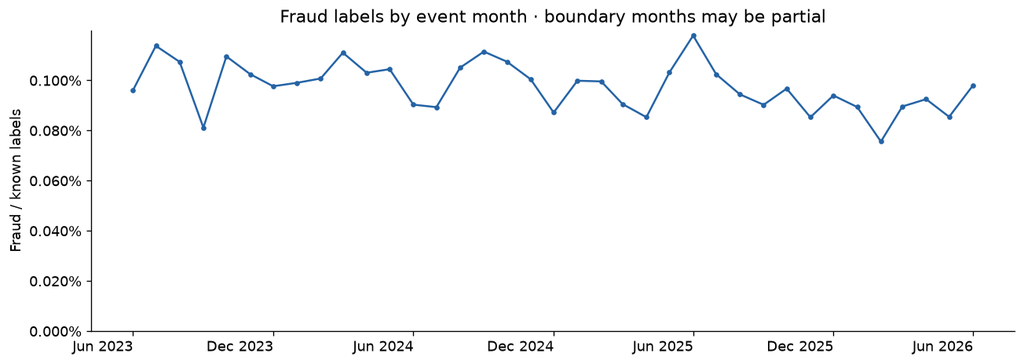

### 9. Monetary coverage and prevention variable roles

Amounts below remain separated by original currency. `amount_usd` is an optional supplied conversion; no exchange rate is inferred. Missing USD values prevent a complete exposure estimate. Score differences by label can reflect how the synthetic data was generated and are not a validated model baseline.

**Observed:** the stored `amount_usd` field is missing on 2,537,456/4,425,008 rows (57.34%). This is largely structural: every native-USD row has a blank `amount_usd`, although `amount` is already in USD. The tables deliberately preserve both source fields; future normalized USD features should explicitly use native-USD `amount`, and only then assess remaining conversion gaps. The amount-band chart currently uses the supplied `amount_usd` only, so its known bands underrepresent native-USD transactions. `fraud_score` is also missing on 885,157 transactions; its provenance and availability at authorization time are not established.

| currency | is_fraud | eligible | amount_known | local_amount |
| --- | --- | --- | --- | --- |
| USD | 0 | 2,435,565 | 2,435,565 | 4,081,545,606.81 |
| COP | 0 | 1,193,329 | 1,193,329 | 7,991,834,289,206.47 |
| ARS | 0 | 791,798 | 791,798 | 464,259,576,356.25 |
| USD | 1 | 2,414 | 2,414 | 3,662,350.45 |
| COP | 1 | 1,115 | 1,115 | 7,370,283,731.32 |
| ARS | 1 | 787 | 787 | 459,696,049.29 |

| currency | is_fraud | usd_known | usd_coverage | usd_amount | absolute_usd_exposure |
| --- | --- | --- | --- | --- | --- |
| USD | 0 | 0 | 0.000% | Unknown | Unknown |
| COP | 0 | 1,133,945 | 95.024% | 1,899,562,210.53 | 1,899,562,210.53 |
| ARS | 0 | 751,799 | 94.948% | 1,259,218,690.09 | 1,259,218,690.09 |
| USD | 1 | 0 | 0.000% | Unknown | Unknown |
| COP | 1 | 1,063 | 95.336% | 1,774,565.18 | 1,774,565.18 |
| ARS | 1 | 745 | 94.663% | 1,234,984.07 | 1,234,984.07 |

| metric | label | known | median | p95 |
| --- | --- | --- | --- | --- |
| fraud_score | 0 | 3,536,426 | 15.00 | 28.50 |
| fraud_score | 1 | 3,425 | 48.93 | 95.24 |

| Variables | Role | Constraint |
| --- | --- | --- |
| is_fraud | Target label | Never use as a predictor |
| amount, currency, type, channel, location | Candidate input | Verify availability at decision time |
| transaction_date + customer_id | Historical features | Only prior events; use time-based validation |
| fraud_score | Existing derived score | Provenance/timing unknown; no baseline claim |
| transaction_status, response_code | Potential post-decision outcome | Exclude from assumed prevention inputs |
| process_date | Arrival/partition metadata | Do not substitute for event or label availability time |

## Takeaways

### Workflow comparison · evidence versus judgment

[output not shown]

**Decision recommendation (judgment):** take complaint/suspicious-charge intake to the meeting as the leading *conditional* service slice, retain transactional inquiry as the comparator, and give fraud prevention a separate leakage-safe feasibility task. There is no measured ROI or causal benefit in this notebook.

**Proposed next ownership decisions:** Roberto owns this scorecard and the prevention variable/label-timing audit; Andrés reviews transcript intents/slots; Lucas defines the baseline, primary KPI and held-out cases; Manoella establishes reproducible data/tool access. Confirm these assignments with the team; nothing has been sent to them.

**Minimum next proof:** a small reviewed set of normal, ambiguous and human-handoff cases; Spanish and Portuguese coverage; deterministic customer/action permissions; baseline and proposed system on the same held-out workload. Track unsafe cases with denominators, missed/unnecessary handoffs, latency and cost. A fraud classifier or a dashboard is not required to prove the intake slice.

### Validation

Twelve regression tests passed. The notebook ran top-to-bottom in clean kernels on a synthetic fixture, a one-partition smoke subset, a seven-partition controlled subset, and all required data. All contact-reason raw counts and resolution flags were independently recounted from CSV; transaction counts and USD sums were independently checked on one complete partition. This sampled monetary check is not an all-row monetary reconciliation. Visual inspection and independent code review complete the handoff; no training, publication or external messages were performed.